# Análisis de Llamadas al 911 en la CDMX

Angye Adriana Rosado Salinas y Giovani Eduardo Blanco Flores

15 de Junio 2025

# Introducción

En esta actividad, se realiza un análisis exploratorio del conjunto de datos correspondientes a las llamadas realizadas al número de emergencia 911 en la Ciudad de México durante el primer y segundo semestre de 2021, y el primer semestre de 2022. El objetivo principal es identificar patrones de comportamiento, tendencias temporales y categorías más frecuentes de incidentes reportados por la ciudadanía, utilizando herramientas del lenguaje de programación R, como las librerías dplyr, lubridate y tidyr.

El conjunto de datos analizado contiene información detallada sobre cada llamada, como la fecha y hora de creación y cierre del incidente, la alcaldía donde ocurrió, la categoría del evento y su clasificación. A través del procesamiento y análisis de esta información, se busca responder preguntas clave como: ¿En qué días y horarios ocurren más emergencias? ¿Qué tipos de incidentes son más frecuentes? ¿Qué proporción de llamadas son falsas alarmas? Los resultados se presentan mediante gráficos y resúmenes estadísticos que permiten interpretar los datos de forma clara y accesible.

# Objetivos de Analisis

1. Identificación de patrones temporales:

Determinar qué día de la semana se registran más incidentes.

Analizar la distribución horaria de los incidentes.

2. Análisis por categoría de incidente:

Comparar la frecuencia de llamadas en diferentes categorías como delito, emergencia y urgencia médica.

Estimar promedios de incidentes por tipo y por alcaldía.

3. Detección de falsos positivos:

Calcular el porcentaje de llamadas clasificadas como falsas alarmas para evaluar eficiencia y veracidad de reportes.

# Origen y estructura de los datos

Los datos utilizados en este proyecto provienen del portal de datos abiertos de la CDMX (https://datos.cdmx.gob.mx/dataset/llamadas-numero-de-atencion-a-emergencias-911).

El conjunto contiene información de incidentes registrados, incluyendo campos como:

- `fecha_creacion`: fecha y hora en que se recibió el reporte.
- `fecha_cierre`: fecha y hora en que se resolvió el incidente.
- `alcaldia_cierre`: demarcación donde se atendió el incidente.
- `categoria_incidente_c4`: tipo de incidente reportado.
- `clas_con_f_alarma`: si el incidente fue una falsa alarma o no.

# Incidente por mes, alcaldia y promedio de incidentes por categoria.

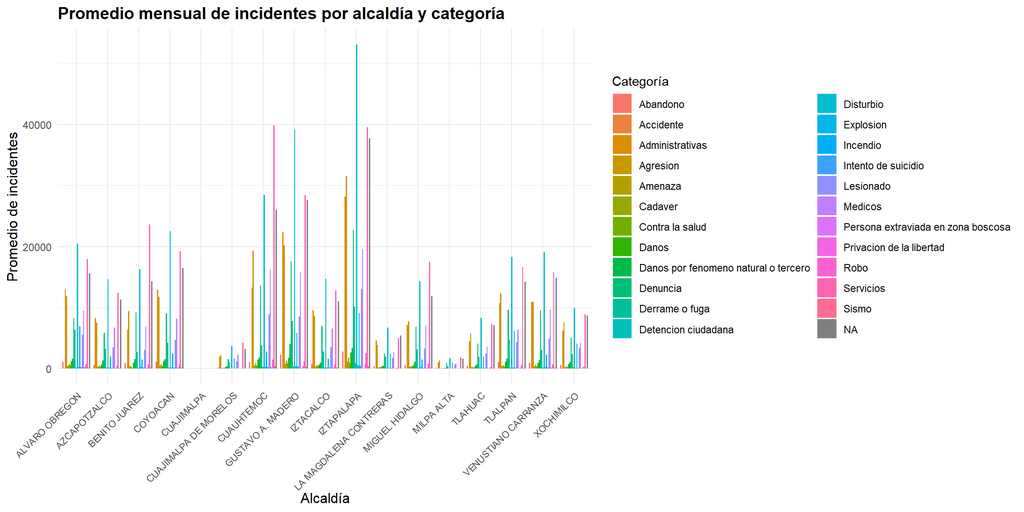

**Hallazgo:**

Detectar estacionalidades o picos anómalos.

Relacionar ciertos aumentos de incidentes con eventos sociales, climáticos o festividades (por ejemplo, más robos en diciembre o más incendios en temporada seca).

Este tipo de análisis es clave para la planeación anticipada de recursos. Si un mes históricamente tiene mayor número de incidentes, se pueden reforzar las unidades operativas antes de que ocurra.

Incidentes por alcaldía Este componente territorial identifica zonas con alta frecuencia de incidentes, lo cual es crítico para:

Detectar focos rojos en materia de seguridad pública, salud o gestión de emergencias.

Evaluar la efectividad de las estrategias ya implementadas (patrullaje, cámaras, servicios médicos).

Un alto número de reportes en determinadas alcaldías puede correlacionarse con:

Densidad poblacional elevada.

Condiciones socioeconómicas más vulnerables.

Deficiencias estructurales en servicios públicos.

También puede servir para priorizar inversiones públicas o ubicar nuevas instalaciones (centros de atención, ambulancias, estaciones de policía).

Promedio de incidentes por categoría Este análisis permite observar cuáles tipos de incidentes son recurrentemente más frecuentes en términos proporcionales, independientemente del total mensual.

Es útil para comparar la evolución interna del sistema de atención, por ejemplo:

Si los promedios de “delito” superan sistemáticamente a los de “emergencia médica”, se evidencia la necesidad de redirigir esfuerzos policiales.

Si una categoría muestra incrementos sostenidos en su promedio, puede representar una tendencia emergente (como más incidentes relacionados con salud mental o violencia intrafamiliar).

Esta métrica ayuda a evaluar la eficiencia y cobertura de los servicios según su especialización.

# Día de la semana con mayor numero de incidentes y total de llamadas

```
## El día con más incidentes fue: 7 con
## un total de 325184 llamadas.
```

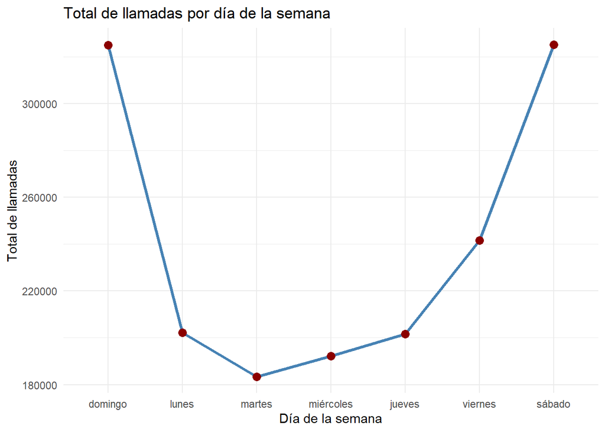

# Distribucion de incidencias por hora del dia para categorias como “delito, emergencia y urgencia medica”

```
##
##     DELITO EMERGENCIA
##     377511     142646
```

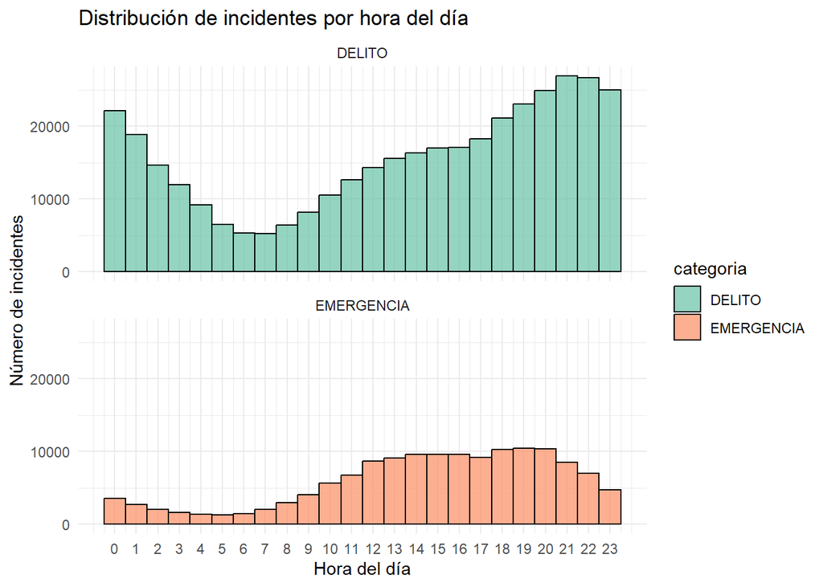

# Porcentaje de llamadas que clasificadas como Falsas

```
## El porcentaje general de llamadas clasificadas como 'Falsa Alarma' es: 0.03 %
```

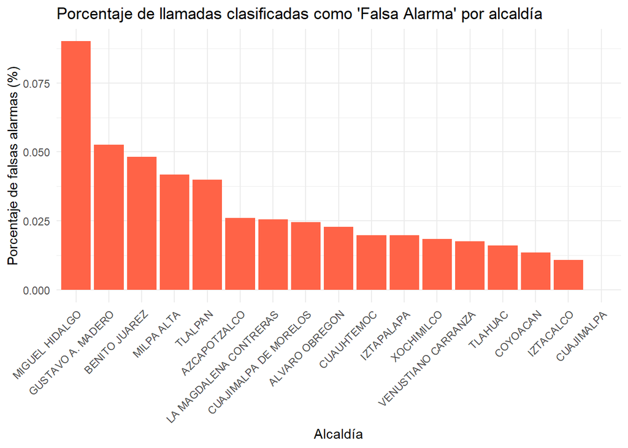

**Hallazgo:**

El porcentaje de llamadas clasificadas como “falsa alarma” es del 0.03%. Esta proporción extremadamente baja indica un alto nivel de confiabilidad en los reportes ciudadanos. En sistemas de atención de emergencias, las llamadas falsas suelen entorpecer operaciones y desperdiciar recursos. Por tanto, este resultado refleja una buena educación cívica, filtrado adecuado en los centros de atención o incluso protocolos efectivos de validación. No obstante, aún se pueden estudiar los casos específicos de falsas alarmas para identificar patrones: si se concentran en ciertas zonas, franjas horarias o dispositivos (por ejemplo, llamadas automáticas o erróneas desde sistemas de alarma domésticos).

# Reflexion

El análisis de los datos presentados en el documento revela patrones relevantes tanto en la temporalidad, ubicación geográfica como en la naturaleza de los incidentes, lo que constituye una base sólida para la toma de decisiones en los ámbitos de seguridad pública, salud, protección civil y planificación urbana.

En cuanto al porcentaje de llamadas clasificadas como falsas alarmas (0.03%), este resultado es especialmente positivo, ya que indica un altísimo grado de veracidad en los reportes ciudadanos, lo que se traduce en una utilización más eficiente de los recursos de respuesta. Esto sugiere también que la ciudadanía tiene un conocimiento adecuado del uso correcto de los sistemas de emergencia, o bien que los mecanismos de filtro son eficaces para detectar reportes inexactos o maliciosos.

En resumen, el análisis explorado no solo ofrece una lectura detallada del comportamiento ciudadano frente a situaciones de riesgo o necesidad, sino que se convierte en una herramienta fundamental para la formulación de políticas públicas informadas, la mejora en la gestión de recursos y la construcción de ciudades más seguras, eficientes y resilientes. Se recomienda dar continuidad a este tipo de análisis mediante la incorporación de capas adicionales de datos (clima, festividades, eventos deportivos, etc.) y mediante el uso de herramientas predictivas que ayuden a anticipar crisis y mejorar la capacidad de respuesta del sistema.

# Proyectos futuros

Este tipo de análisis puede ampliarse para incluir:

- Predicciones de demanda por zona y horario
- Análisis de tiempos de respuesta por tipo de incidente
- Uso de mapas geográficos para ubicar incidentes
- Modelos de aprendizaje automático para detectar patrones anómalos